# Transformations, Two Predictors and Their Interaction

# Part C: Data Analysis

For Part C of the assignment, we will narrow from a global perspective to a local one. You will analyze a subset of data collected on Zoom from a math intervention study. Participants were a convenience sample recruited from the Madison, WI area.

Integer arithmetic skills (e.g., addition with positive and negative numbers) are important for more advanced mathematical performance and learning. This study investigated factors associated with fluency in integer addition in children in fifth through seventh grade (N = 62, Mage = 11.44 years). The researchers examined demographic, attitudinal, and cognitive factors, which included age, grade, gender, mathematics anxiety, understanding of the Additive Inverse principle (i.e., the sum of any number and its inverse is 0), and use of mathematically precise language (“negative” rather than “minus” on a related task).

```r
d1 <- read_csv("/Users/yanzhu//Desktop/sample_code/Design and Analysis of Psychological Experiments/Data/integer_fluency.csv") %>% clean_names()
describe(d1)
```

```
##                  vars  n   mean    sd median trimmed   mad min max range  skew
## sub_id              1 62  48.29 19.32   48.5   48.50 24.46  11  80    69 -0.08
## age_months          2 62 137.29  7.90  134.5  136.86  8.15 122 156    34  0.42
## grade_level         3 62   1.73  0.77    2.0    1.66  1.48   1   3     2  0.50
## gender              4 62   0.60  0.53    1.0    0.60  0.00   0   2     2 -0.05
## integer_fluency     5 62  16.05  6.73   16.0   16.58  7.41   0  25    25 -0.46
## ma_1                6 62   1.39  0.64    1.0    1.26  0.00   1   3     2  1.36
## ma_2                7 62   2.10  0.92    2.0    2.02  1.48   1   5     4  0.69
## ma_3                8 62   1.16  0.41    1.0    1.06  0.00   1   3     2  2.46
## ma_4                9 62   2.15  1.02    2.0    2.02  1.48   1   5     4  0.80
## ma_5               10 62   2.68  1.08    3.0    2.66  1.48   1   5     4  0.27
## ma_6               11 62   1.47  0.86    1.0    1.26  0.00   1   5     4  2.13
## ma_7               12 62   1.16  0.49    1.0    1.04  0.00   1   4     3  3.77
## ma_8               13 62   2.26  0.92    2.0    2.20  1.48   1   4     3  0.22
## ma_9               14 62   1.56  0.80    1.0    1.44  0.00   1   4     3  1.11
## additive_inverse   15 62   0.40  0.98    0.0    0.14  0.00   0   4     4  2.71
## precise_language   16 62   3.00  1.33    4.0    3.24  0.00   0   4     4 -1.07
## working_memory     17 62   4.53  1.99    4.0    4.54  1.48   0   9     9  0.00
##                  kurtosis   se
## sub_id              -1.21 2.45
## age_months          -0.90 1.00
## grade_level         -1.19 0.10
## gender              -1.30 0.07
## integer_fluency     -0.60 0.86
## ma_1                 0.62 0.08
## ma_2                 0.28 0.12
## ma_3                 5.58 0.05
## ma_4                 0.23 0.13
## ma_5                -0.75 0.14
## ma_6                 4.49 0.11
## ma_7                16.84 0.06
## ma_8                -0.86 0.12
## ma_9                 0.03 0.10
## additive_inverse     6.62 0.12
## precise_language    -0.10 0.17
## working_memory      -0.46 0.25
```

```r
skim(d1)
```

Data summary

| Name | d1 |
| --- | --- |
| Number of rows | 62 |
| Number of columns | 17 |
| _______________________ |  |
| Column type frequency: |  |
| numeric | 17 |
| ________________________ |  |
| Group variables | None |

**Variable type: numeric**

| skim_variable | n_missing | complete_rate | mean | sd | p0 | p25 | p50 | p75 | p100 | hist |
| --- | --- | --- | --- | --- | --- | --- | --- | --- | --- | --- |
| sub_id | 0 | 1 | 48.29 | 19.32 | 11 | 32.25 | 48.5 | 64.75 | 80 | ▅▇▇▇▇ |
| age_months | 0 | 1 | 137.29 | 7.90 | 122 | 131.00 | 134.5 | 144.75 | 156 | ▁▇▃▅▁ |
| grade_level | 0 | 1 | 1.73 | 0.77 | 1 | 1.00 | 2.0 | 2.00 | 3 | ▇▁▆▁▃ |
| gender | 0 | 1 | 0.60 | 0.53 | 0 | 0.00 | 1.0 | 1.00 | 2 | ▆▁▇▁▁ |
| integer_fluency | 0 | 1 | 16.05 | 6.73 | 0 | 12.00 | 16.0 | 22.00 | 25 | ▂▁▇▅▇ |
| ma_1 | 0 | 1 | 1.39 | 0.64 | 1 | 1.00 | 1.0 | 2.00 | 3 | ▇▁▂▁▁ |
| ma_2 | 0 | 1 | 2.10 | 0.92 | 1 | 1.00 | 2.0 | 3.00 | 5 | ▅▇▅▁▁ |
| ma_3 | 0 | 1 | 1.16 | 0.41 | 1 | 1.00 | 1.0 | 1.00 | 3 | ▇▁▁▁▁ |
| ma_4 | 0 | 1 | 2.15 | 1.02 | 1 | 1.00 | 2.0 | 3.00 | 5 | ▆▇▅▁▁ |
| ma_5 | 0 | 1 | 2.68 | 1.08 | 1 | 2.00 | 3.0 | 3.00 | 5 | ▃▇▆▅▁ |
| ma_6 | 0 | 1 | 1.47 | 0.86 | 1 | 1.00 | 1.0 | 2.00 | 5 | ▇▂▁▁▁ |
| ma_7 | 0 | 1 | 1.16 | 0.49 | 1 | 1.00 | 1.0 | 1.00 | 4 | ▇▁▁▁▁ |
| ma_8 | 0 | 1 | 2.26 | 0.92 | 1 | 2.00 | 2.0 | 3.00 | 4 | ▅▇▁▆▂ |
| ma_9 | 0 | 1 | 1.56 | 0.80 | 1 | 1.00 | 1.0 | 2.00 | 4 | ▇▃▁▂▁ |
| additive_inverse | 0 | 1 | 0.40 | 0.98 | 0 | 0.00 | 0.0 | 0.00 | 4 | ▇▁▁▁▁ |
| precise_language | 0 | 1 | 3.00 | 1.33 | 0 | 2.00 | 4.0 | 4.00 | 4 | ▂▁▃▂▇ |
| working_memory | 0 | 1 | 4.53 | 1.99 | 0 | 3.00 | 4.0 | 6.00 | 9 | ▂▃▇▅▂ |

*No, there is no missing data.*

```r
#  Check the reliability of the math anxiety scale. None of the items are reverse coded. What is Cronbach’s alpha of this scale? Do you consider this scale reliable? Why?

ma <- paste("ma_", 1:9, sep = "")
psych::alpha(d1[, ma])
```

```
##
## Reliability analysis
## Call: psych::alpha(x = d1[, ma])
##
##   raw_alpha std.alpha G6(smc) average_r S/N   ase mean   sd median_r
##       0.76      0.77    0.79      0.27 3.3 0.042  1.8 0.48     0.24
##
##     95% confidence boundaries
##          lower alpha upper
## Feldt     0.66  0.76  0.84
## Duhachek  0.68  0.76  0.85
##
##  Reliability if an item is dropped:
##      raw_alpha std.alpha G6(smc) average_r S/N alpha se var.r med.r
## ma_1      0.73      0.73    0.75      0.25 2.7    0.049 0.017  0.22
## ma_2      0.72      0.73    0.75      0.25 2.7    0.049 0.017  0.22
## ma_3      0.76      0.76    0.77      0.28 3.1    0.044 0.020  0.22
## ma_4      0.69      0.71    0.71      0.23 2.4    0.056 0.010  0.21
## ma_5      0.74      0.74    0.77      0.27 2.9    0.047 0.021  0.21
## ma_6      0.76      0.76    0.78      0.28 3.1    0.043 0.023  0.26
## ma_7      0.76      0.76    0.78      0.29 3.2    0.044 0.022  0.28
## ma_8      0.74      0.75    0.76      0.27 3.0    0.047 0.018  0.24
## ma_9      0.75      0.75    0.77      0.28 3.1    0.043 0.023  0.26
##
##  Item statistics
##       n raw.r std.r r.cor r.drop mean   sd
## ma_1 62  0.67  0.67  0.63   0.57  1.4 0.64
## ma_2 62  0.68  0.65  0.62   0.53  2.1 0.92
## ma_3 62  0.42  0.52  0.44   0.34  1.2 0.41
## ma_4 62  0.80  0.77  0.80   0.68  2.1 1.02
## ma_5 62  0.65  0.59  0.52   0.47  2.7 1.08
## ma_6 62  0.51  0.51  0.40   0.34  1.5 0.86
## ma_7 62  0.41  0.48  0.36   0.31  1.2 0.49
## ma_8 62  0.62  0.57  0.51   0.46  2.3 0.92
## ma_9 62  0.50  0.53  0.44   0.34  1.6 0.80
##
## Non missing response frequency for each item
##         1    2    3    4    5 miss
## ma_1 0.69 0.23 0.08 0.00 0.00    0
## ma_2 0.27 0.44 0.23 0.05 0.02    0
## ma_3 0.85 0.13 0.02 0.00 0.00    0
## ma_4 0.29 0.40 0.21 0.06 0.03    0
## ma_5 0.13 0.35 0.27 0.19 0.05    0
## ma_6 0.69 0.21 0.05 0.03 0.02    0
## ma_7 0.87 0.11 0.00 0.02 0.00    0
## ma_8 0.23 0.39 0.29 0.10 0.00    0
## ma_9 0.61 0.23 0.15 0.02 0.00    0
```

*I would consider this scale reliable*

```r
# Create a composite math anxiety score across the nine items. Label the new variable: math_anxiety_total.

d1$math_anxiety_total = varScore(d1,
                  Forward= ma,
                  Reverse= c(),
                  Range=c(1, 5),
                  MaxMiss=0.25,
                  Prorate=T) / 9
```

```r
# Because only one participant identified as non-binary and the following research questions are examining differences between male and female participants, remove the one non-binary participant from the dataset. Note: Future studies should recruit samples with a wider variety of gender identities to examine the different kinds of experiences children have in education depending on their gender expression!!!!!

d1 <- d1[d1$sub_id != 42, ]
```

```r
m2 <- lm(integer_fluency ~ age_months + grade_level + gender + math_anxiety_total + additive_inverse + precise_language, data = d1)

summary(m2)
```

```
##
## Call:
## lm(formula = integer_fluency ~ age_months + grade_level + gender +
##     math_anxiety_total + additive_inverse + precise_language,
##     data = d1)
##
## Residuals:
##     Min      1Q  Median      3Q     Max
## -9.4910 -3.7377 -0.2791  3.9820 10.3373
##
## Coefficients:
##                    Estimate Std. Error t value Pr(>|t|)
## (Intercept)        -12.2986    17.9215  -0.686   0.4955
## age_months           0.1932     0.1469   1.316   0.1938
## grade_level          2.0193     1.5319   1.318   0.1930
## gender               2.3013     1.4478   1.590   0.1178
## math_anxiety_total  -3.4751     1.4659  -2.371   0.0214 *
## additive_inverse     0.2000     0.7221   0.277   0.7829
## precise_language     1.0255     0.5457   1.879   0.0656 .
## ---
## Signif. codes:  0 '***' 0.001 '**' 0.01 '*' 0.05 '.' 0.1 ' ' 1
##
## Residual standard error: 5.336 on 54 degrees of freedom
## Multiple R-squared:  0.4307, Adjusted R-squared:  0.3675
## F-statistic:  6.81 on 6 and 54 DF,  p-value: 2.048e-05
```

```r
#X on Y
m1 = lm(integer_fluency ~ gender, d1)
summary(m1)
```

```
##
## Call:
## lm(formula = integer_fluency ~ gender, data = d1)
##
## Residuals:
##      Min       1Q   Median       3Q      Max
## -17.6286  -3.6286   0.3714   4.3714  11.3846
##
## Coefficients:
##             Estimate Std. Error t value Pr(>|t|)
## (Intercept)   13.615      1.266   10.75 1.59e-15 ***
## gender         4.013      1.672    2.40   0.0196 *
## ---
## Signif. codes:  0 '***' 0.001 '**' 0.01 '*' 0.05 '.' 0.1 ' ' 1
##
## Residual standard error: 6.458 on 59 degrees of freedom
## Multiple R-squared:  0.08897,    Adjusted R-squared:  0.07353
## F-statistic: 5.762 on 1 and 59 DF,  p-value: 0.01955
```

```r
#X on M
m2 = lm(math_anxiety_total ~ gender, d1)
summary(m2)
```

```
##
## Call:
## lm(formula = math_anxiety_total ~ gender, data = d1)
##
## Residuals:
##     Min      1Q  Median      3Q     Max
## -0.7682 -0.3238 -0.1016  0.2318  1.4540
##
## Coefficients:
##             Estimate Std. Error t value Pr(>|t|)
## (Intercept)  1.79487    0.09486  18.921   <2e-16 ***
## gender      -0.02662    0.12523  -0.213    0.832
## ---
## Signif. codes:  0 '***' 0.001 '**' 0.01 '*' 0.05 '.' 0.1 ' ' 1
##
## Residual standard error: 0.4837 on 59 degrees of freedom
## Multiple R-squared:  0.0007651,  Adjusted R-squared:  -0.01617
## F-statistic: 0.04518 on 1 and 59 DF,  p-value: 0.8324
```

```r
#M on Y controlling for X
m3 = lm(integer_fluency ~ math_anxiety_total + gender, d1)
summary(m3)
```

```
##
## Call:
## lm(formula = integer_fluency ~ math_anxiety_total + gender, data = d1)
##
## Residuals:
##      Min       1Q   Median       3Q      Max
## -14.6275  -4.1335   0.2017   4.1371  12.1665
##
## Coefficients:
##                    Estimate Std. Error t value Pr(>|t|)
## (Intercept)          20.457      3.254   6.286 4.58e-08 ***
## math_anxiety_total   -3.812      1.680  -2.269   0.0270 *
## gender                3.912      1.617   2.420   0.0187 *
## ---
## Signif. codes:  0 '***' 0.001 '**' 0.01 '*' 0.05 '.' 0.1 ' ' 1
##
## Residual standard error: 6.242 on 58 degrees of freedom
## Multiple R-squared:  0.1632, Adjusted R-squared:  0.1344
## F-statistic: 5.657 on 2 and 58 DF,  p-value: 0.005694
```

*No, condition 2 is not satisfied.*

```r
#X on Y
m1 = lm(integer_fluency ~ age_months, d1)
summary(m1)
```

```
##
## Call:
## lm(formula = integer_fluency ~ age_months, data = d1)
##
## Residuals:
##     Min      1Q  Median      3Q     Max
## -13.290  -4.005   0.281   3.995  12.567
##
## Coefficients:
##             Estimate Std. Error t value Pr(>|t|)
## (Intercept) -42.8511    13.1993  -3.246  0.00193 **
## age_months    0.4286     0.0961   4.460 3.74e-05 ***
## ---
## Signif. codes:  0 '***' 0.001 '**' 0.01 '*' 0.05 '.' 0.1 ' ' 1
##
## Residual standard error: 5.851 on 59 degrees of freedom
## Multiple R-squared:  0.2521, Adjusted R-squared:  0.2394
## F-statistic: 19.89 on 1 and 59 DF,  p-value: 3.742e-05
```

```r
#X on M
m2 = lm(precise_language ~ age_months, d1)
summary(m2)
```

```
##
## Call:
## lm(formula = precise_language ~ age_months, data = d1)
##
## Residuals:
##     Min      1Q  Median      3Q     Max
## -2.9305 -0.7895  0.4589  0.9286  1.7272
##
## Coefficients:
##             Estimate Std. Error t value Pr(>|t|)
## (Intercept) -3.45802    2.91937  -1.185    0.241
## age_months   0.04697    0.02125   2.210    0.031 *
## ---
## Signif. codes:  0 '***' 0.001 '**' 0.01 '*' 0.05 '.' 0.1 ' ' 1
##
## Residual standard error: 1.294 on 59 degrees of freedom
## Multiple R-squared:  0.07646,    Adjusted R-squared:  0.0608
## F-statistic: 4.884 on 1 and 59 DF,  p-value: 0.03099
```

```r
#M on Y controlling for X
m3 = lm(integer_fluency ~ age_months + precise_language, d1)
summary(m3)
```

```
##
## Call:
## lm(formula = integer_fluency ~ age_months + precise_language,
##     data = d1)
##
## Residuals:
##      Min       1Q   Median       3Q      Max
## -10.1177  -4.9456  -0.0985   3.9918  13.0159
##
## Coefficients:
##                   Estimate Std. Error t value Pr(>|t|)
## (Intercept)      -38.78098   13.00555  -2.982 0.004183 **
## age_months         0.37327    0.09738   3.833 0.000314 ***
## precise_language   1.17700    0.57321   2.053 0.044556 *
## ---
## Signif. codes:  0 '***' 0.001 '**' 0.01 '*' 0.05 '.' 0.1 ' ' 1
##
## Residual standard error: 5.698 on 58 degrees of freedom
## Multiple R-squared:  0.3028, Adjusted R-squared:  0.2787
## F-statistic: 12.59 on 2 and 58 DF,  p-value: 2.868e-05
```

*So far we do have evidence for the proposed mediation analysis.*

Test the indirect effect of age on integer fluency through precise language. Set the seed to 123. Is the indirect effect significant?

```r
medmodel <- '
precise_language ~ A * age_months
integer_fluency ~ CPRIME * age_months + B * precise_language
AB:= A*B
Total := CPRIME + A*B
'
set.seed(123)
fit1 <- sem(medmodel, data = d1, se = "bootstrap", bootstrap = 5000)

parameterEstimates(fit1, ci = TRUE, level = 0.95, boot.ci.type = "perc", zstat = F)
```

```
##                lhs op              rhs  label    est    se ci.lower ci.upper
## 1 precise_language  ~       age_months      A  0.047 0.018    0.014    0.086
## 2  integer_fluency  ~       age_months CPRIME  0.373 0.081    0.213    0.537
## 3  integer_fluency  ~ precise_language      B  1.177 0.750   -0.196    2.750
## 4 precise_language ~~ precise_language         1.620 0.272    1.039    2.097
## 5  integer_fluency ~~  integer_fluency        30.867 4.438   21.120   38.490
## 6       age_months ~~       age_months        60.770 0.000   60.770   60.770
## 7               AB :=              A*B     AB  0.055 0.044   -0.008    0.161
## 8            Total :=       CPRIME+A*B  Total  0.429 0.084    0.273    0.604
```

Write-up the results:

To investigate whether age relates to integer fluency (i.e., quickly solving integer addition problems), we fit a General Linear Model predicting integer fluency from age in months. Consistent with the existing literature, older participants performed higher on the integer fluency task, 𝐹(1,59)=19.89, 𝑝<0.001, 𝜂2=.25.

Now, you will add a (fake) variable to your dataframe. Pretend we had participants complete the Backwards Digit Span Task which measures working memory. Participants receive a score 1-9 with a higher value indicating higher working memory capacity. Merge the dataframe from C1-C10 with working_memory.csv.

```r
drop <- c("working_memory")
d1 = d1[,!(names(d1) %in% drop)]

d2 = read.csv("/Users/yanzhu/Desktop/sample_code/Design and Analysis of Psychological Experiments/Data/working_memory.csv")
d3 = full_join(d1, d2)
m_23 = lm(integer_fluency ~ working_memory + age_months, d3)
summary(m_23)
```

```
##
## Call:
## lm(formula = integer_fluency ~ working_memory + age_months, data = d3)
##
## Residuals:
##      Min       1Q   Median       3Q      Max
## -18.9946  -3.0389   0.1247   3.3413  12.7537
##
## Coefficients:
##                 Estimate Std. Error t value Pr(>|t|)
## (Intercept)    -33.77283   11.96816  -2.822 0.006528 **
## working_memory   1.43454    0.35449   4.047 0.000156 ***
## age_months       0.31520    0.09006   3.500 0.000901 ***
## ---
## Signif. codes:  0 '***' 0.001 '**' 0.01 '*' 0.05 '.' 0.1 ' ' 1
##
## Residual standard error: 5.211 on 58 degrees of freedom
## Multiple R-squared:  0.4168, Adjusted R-squared:  0.3967
## F-statistic: 20.72 on 2 and 58 DF,  p-value: 1.619e-07
```

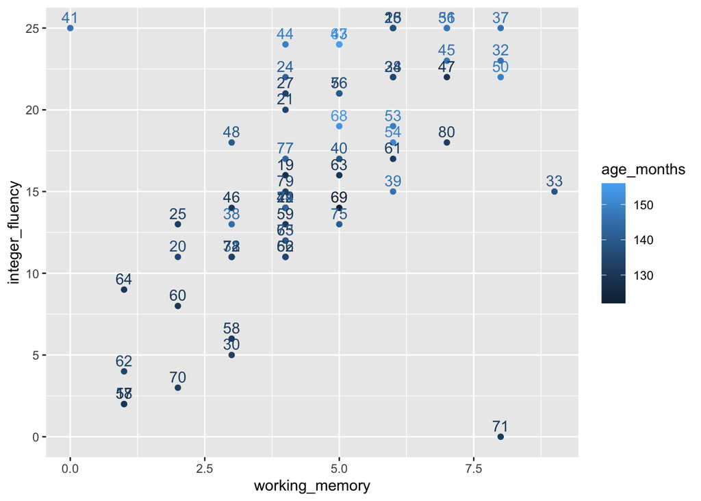

```r
# Consider one more additional exploratory hypothesis: We hypothesize working memory predicts integer fluency controlling for age. Fit a linear model predicting integer fluency from working memory and age. Do not center your predictors.

ggplot(data = d3, aes(x = working_memory, y = integer_fluency, color = age_months, label = sub_id)) +
  geom_point() + geom_text(vjust = -.5)
```

```r
x_hats <- modelCaseAnalysis(m_23, Type = "HATVALUES")
```

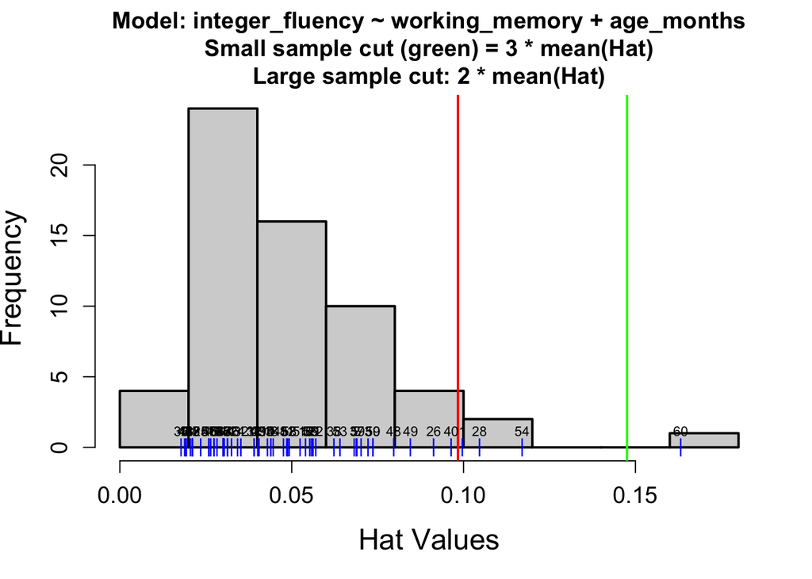

```r
x_resids <- modelCaseAnalysis(m_23, Type = "RESIDUALS")
```

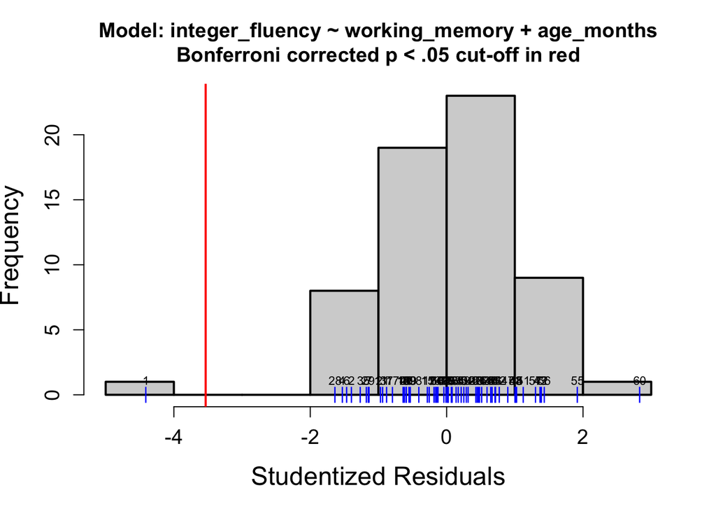

*Row 1 (sub_id 71) is a regression outlier. It has a large residual.*

```r
x_cooks <- modelCaseAnalysis(m_23, Type = "COOKSD")
```

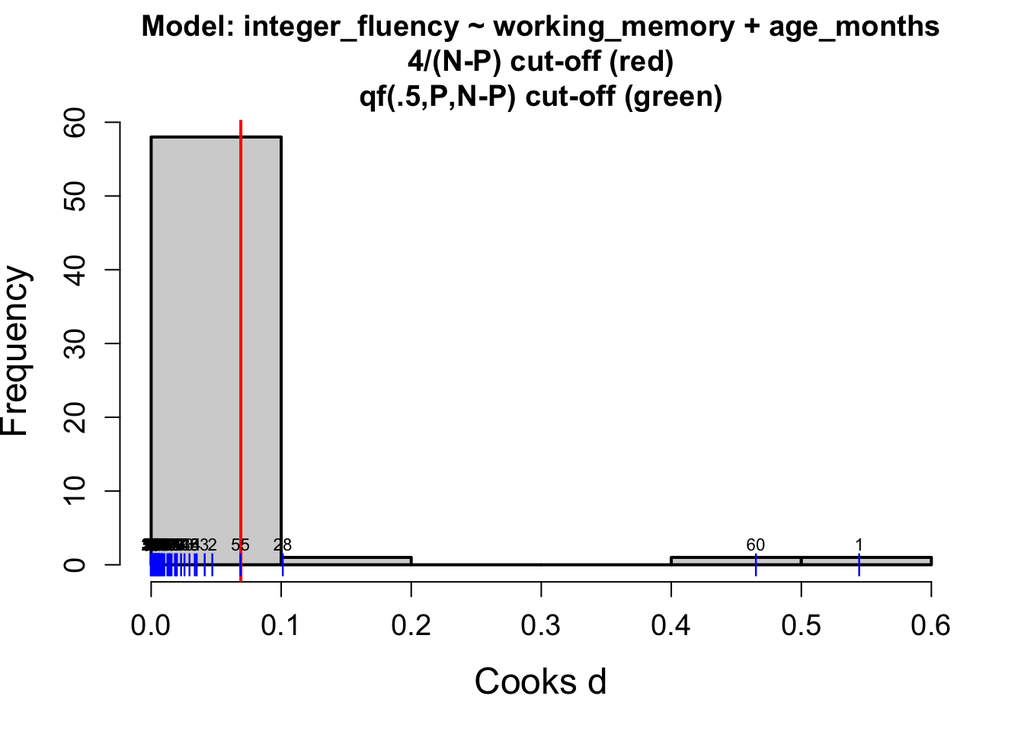

*Rows 1 and 60 OR sub_IDs 71 and 41*

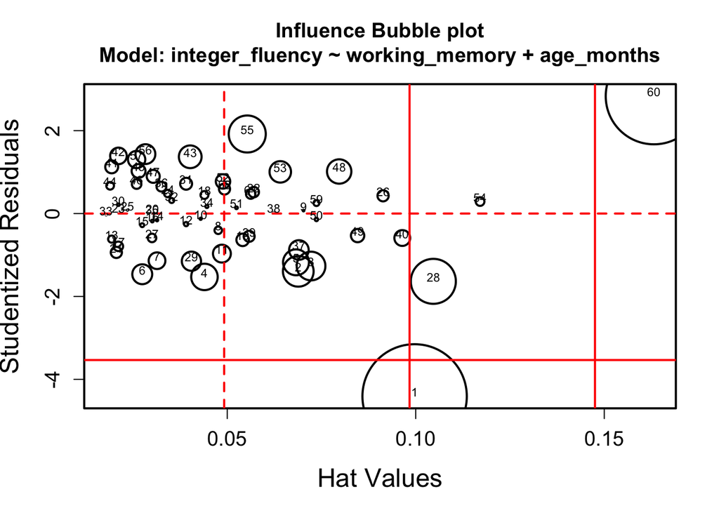

```r
x_infs <- modelCaseAnalysis(m_23, Type = "INFLUENCEPLOT")
```

*Rows 1 and 60*

*OR sub_IDs 71 and 41*

If you had to give the researchers advice about whether to remove any of the participants, what would you say?

*I would remove the two data points: 1 and 60.*

Remove the influential participants and rerun the model from C12 with uncentered predictors. Interpret b0, b1, and b2. How did the SE for each predictor change?

SE decreased for both predictors!

```r
d3[c(1, 60),]
```

```
## # A tibble: 2 × 18
##   sub_id age_months grade_level gender integer_fluency  ma_1  ma_2  ma_3  ma_4
##    <dbl>      <dbl>       <dbl>  <dbl>           <dbl> <dbl> <dbl> <dbl> <dbl>
## 1     71        131           1      1               0     2     3     1     4
## 2     41        146           2      0              25     1     1     1     2
## # ℹ 9 more variables: ma_5 <dbl>, ma_6 <dbl>, ma_7 <dbl>, ma_8 <dbl>,
## #   ma_9 <dbl>, additive_inverse <dbl>, precise_language <dbl>,
## #   math_anxiety_total <dbl>, working_memory <int>
```

```r
d3_cut = d3[-c(1, 60),]

m_d3_cut = lm(integer_fluency ~ working_memory + age_months, d3_cut)
summary(m_d3_cut)
```

```
##
## Call:
## lm(formula = integer_fluency ~ working_memory + age_months, data = d3_cut)
##
## Residuals:
##      Min       1Q   Median       3Q      Max
## -11.5861  -2.5862  -0.4394   2.6630   7.1748
##
## Coefficients:
##                 Estimate Std. Error t value Pr(>|t|)
## (Intercept)    -17.24058    9.65182  -1.786   0.0795 .
## working_memory   2.28668    0.30787   7.427 6.81e-10 ***
## age_months       0.16724    0.07387   2.264   0.0275 *
## ---
## Signif. codes:  0 '***' 0.001 '**' 0.01 '*' 0.05 '.' 0.1 ' ' 1
##
## Residual standard error: 4.035 on 56 degrees of freedom
## Multiple R-squared:  0.6144, Adjusted R-squared:  0.6006
## F-statistic: 44.61 on 2 and 56 DF,  p-value: 2.586e-12
```